# Métodos Quantitativos I

Gabarito Lista III: Correlação, causalidade e DAGs

Professores: Daniel Grimaldi e Arthur Bragança

2025-07-09

### *dgp*

1. *n.id*: um escalar que define a quantidade de indivíduos que compõem a amostra;
2. *delta_universidade*: um escalar que define o impacto (em reais) de concluir uma universidade sobre a renda futura do indivíduo;
3. *delta_publica* um escalar que define o impacto (em reais) de se concluir uma universidade pública vis-à-vis uma universidade particular sobre a renda futura do indivíduo;
4. *peso_alpha*: um escalar que define o peso relativo[^1] de habilidades não observadas sobre o acesso à universidade - seja pública ou privada.

O **Chunk 1** abaixo carrega essa função

**Chunk 1: Carrega função dgp da página do curso no Github**

```r
source("https://raw.githubusercontent.com/dgrimald/Econometria_ENAP/refs/heads/main/Aula%204/dgp.R")
```

### Cria base de dados

Usando a função que você acabou de carregar, crie, dentro do **Chunk 2** uma amostra de dados com as seguintes especificações:

- 5000 indivíduos;
- o impacto de se concluir uma universidade sobre a renda é de BR$ 6000,00;
- o impacto adicional sobre o salário de cursar uma universidade pública vis-à-vis uma universidade pública é de - BR$800,00;
- o peso das habilidades intrínsecas é o maior possível (1).

Dê o nome de **sample_1** a essa base de dados que você vai criar e use a função *head* para incluir no seu relatório as 20 primeiras linhas de **sample_1**.

**lembre-se de ajustar o argumento eval para TRUE quando você for executar o arquivo (o mesmo vale para todos os chunks adiante)**.

**Chunk 2: Usa função dgp para criar amostra**

```r
sample_1 <- dgp(n.id=5000, delta_universidade = 6000, delta_publica = -800, peso_alpha = 1)
head(sample_1, 20)
```

```
## # A tibble: 20 × 8
##       id     t alpha_id   D_u   x_1 cut.off   D_p       y
##    <int> <dbl>    <dbl> <dbl> <dbl>   <dbl> <dbl>   <dbl>
##  1     1     0    2.22      0     6  -0.136     0  89453.
##  2     1     1    2.22      0     6  -0.136     0  89553.
##  3     2     0   -1.12      0     1  -0.136     0  71093.
##  4     2     1   -1.12      0     1  -0.136     0  71192.
##  5     3     0    7.10      0     9  -0.136     0 116312.
##  6     3     1    7.10      1    13   1.28      1 121613.
##  7     4     0    0.749     0     6  -0.136     0  81379.
##  8     4     1    0.749     0     6  -0.136     0  81478.
##  9     5     0    4.57      0     9  -0.136     0 102393.
## 10     5     1    4.57      1    13   1.28      0 108493.
## 11     6     0    1.66      0     9  -0.136     0  86400.
## 12     6     1    1.66      1    13   1.28      0  92499.
## 13     7     0    4.92      0     9  -0.136     0 104308.
## 14     7     1    4.92      1    13   1.28      0 110405.
## 15     8     0    0.947     0     3  -0.136     0  82465.
## 16     8     1    0.947     0     3  -0.136     0  82566.
## 17     9     0   -1.46      0     0  -0.136     0  69221.
## 18     9     1   -1.46      0     0  -0.136     0  69321.
## 19    10     0    4.42      0     9  -0.136     0 101572.
## 20    10     1    4.42      1    13   1.28      0 107672.
```

### DAG

Considerando o pdg definido pela função *dgp*, use o **Chunk 3** para criar um gráfico de DAG mostrando todos os *paths* entre o acesso a univesidade pública e a renda futura - tal qual o que fizemos no slide 45 da Aula 4. Lembre-se de incluir as seguintes variáveis: $y \text{ (renda)}, x_1\text{ (anos de estudo)}, \alpha_{i} \text{ (habilidade intrínseca)}, D_u \text{ (dummy de acesso à universidade)} \text{ e } D_p \text{ (dummy de acesso à universidade pública)}$.

**Chunk 3: DAG: *paths* entre D_p e *y***

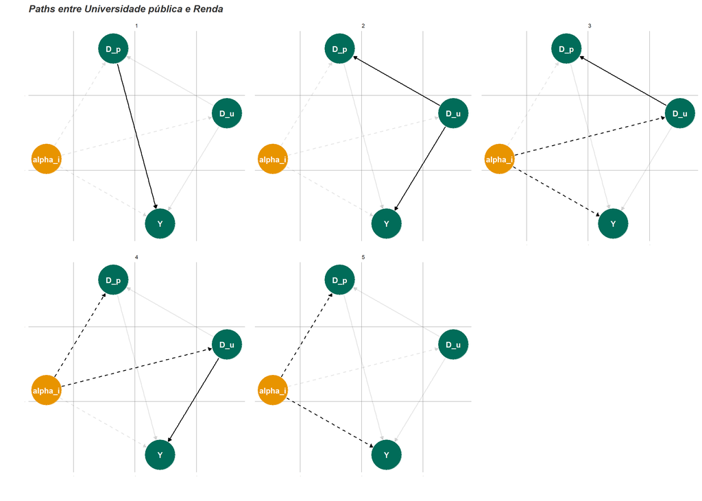

```r
set.seed(13)
ex_dag <- dagify(D_u ~ alpha_i,
                  D_p ~ D_u + alpha_i,
                  Y ~ D_u + D_p + alpha_i) %>%
  tidy_dagitty() %>%
  mutate(color_node=ifelse(name=="alpha_i", "Unobserved", "Observed"),
         edge_line=ifelse(name=="alpha_i", 2, 1))

fig.data <- dag_paths(ex_dag, from = "D_p", to="Y") %>%
  distinct(set, name, to, .keep_all=TRUE) %>%
  mutate(show_node=ifelse(is.na(path), 0, 1),
         show_line=case_when(is.na(path) ~ 0.1,
                             TRUE ~ 1))

fig <- ggplot(data=fig.data, aes(
    x = x,
    y = y,
    xend = xend,
    yend = yend
  )) +
  geom_dag_point(aes(fill=color_node, color=color_node), size=20, show.legend = FALSE) +
  scale_color_manual(values = c(cores$verde_escuro, cores$amarelo_escuro)) +
  geom_dag_edges(aes(edge_linetype=edge_line, edge_alpha=show_line), show.legend = FALSE)+
  geom_dag_text() +
  labs(title="Paths entre Universidade pública e Renda",
       y="",
       x="") +
  facet_wrap(vars(set)) +
  tema_base_fundobranco() +
  theme(axis.line.x = element_line(colour=NA),
        axis.text.x = element_text(size=0),
        axis.text.y = element_text(size=0))
fig
```

### Correlações

No **Chunk 4**, calcule a correlação entre o salário (*y*) e o acesso à universidade (*D_u*). Lembre-se de levar em conta apenas as observações do período 1 (**t==1**).

**Chunk 4: Correlação entre acesso a universidade e renda futura**

```r
cor(sample_1$y[sample_1$t==1], sample_1$D_u[sample_1$t==1])
```

```
## [1] 0.724881
```

No **Chunk 5**, calcule a correlação entre o salário (*y*) e o acesso à universidade pública (*D_p*). Lembre-se de levar em conta apenas as observações do período 1 (**t==1**).

**Chunk 5: Correlação entre acesso a universidade e renda futura**

```r
cor(sample_1$y[sample_1$t==1], sample_1$D_p[sample_1$t==1])
```

```
## [1] 0.5999846
```

### Estimadores OLS

Sabendo que $D_p$ equivale a uma dummy que determina os indivíduos que fizeram faculdade pública e que $D_u$ equivale a uma dummy que determina os indivíduos que fizeram faculdade, use *sample_1* para estimar, dentro do **Chunk 6**, as seguintes regressões usando mínimos quadrados ordinários (OLS):

$$(1) \; y_{i} = \alpha_0 + \delta_u D_u \\
(2) \; y_{i} = \alpha_0 + \delta_p D_p \\
(3) \; y_{i} = \alpha_0 + \delta_u D_u + \delta_p D_p \\$$

Lembre-se de levar em conta apenas as observações do período 1 (**t==1**).

**Chunk 6: Estimadores OLS**

```r
reg_1 <- lm(y ~ D_u, data=filter(sample_1, t==1))
reg_2 <- lm(y ~ D_p, data=filter(sample_1, t==1))
reg_3 <- lm(y ~ D_u + D_p, data=filter(sample_1, t==1))
summary(reg_1)
```

```
##
## Call:
## lm(formula = y ~ D_u, data = filter(sample_1, t == 1))
##
## Residuals:
##    Min     1Q Median     3Q    Max
## -63865  -9736    699  11550  48450
##
## Coefficients:
##             Estimate Std. Error t value Pr(>|t|)
## (Intercept)  69965.2      256.2  273.08   <2e-16 ***
## D_u          43096.1      579.3   74.39   <2e-16 ***
## ---
## Signif. codes:  0 '***' 0.001 '**' 0.01 '*' 0.05 '.' 0.1 ' ' 1
##
## Residual standard error: 16250 on 4998 degrees of freedom
## Multiple R-squared:  0.5255, Adjusted R-squared:  0.5254
## F-statistic:  5534 on 1 and 4998 DF,  p-value: < 2.2e-16
```

```r
summary(reg_2)
```

```
##
## Call:
## lm(formula = y ~ D_p, data = filter(sample_1, t == 1))
##
## Residuals:
##    Min     1Q Median     3Q    Max
## -67636 -11181   -173  12264  40142
##
## Coefficients:
##             Estimate Std. Error t value Pr(>|t|)
## (Intercept)  73736.2      281.0  262.45   <2e-16 ***
## D_p          47633.3      898.4   53.02   <2e-16 ***
## ---
## Signif. codes:  0 '***' 0.001 '**' 0.01 '*' 0.05 '.' 0.1 ' ' 1
##
## Residual standard error: 18870 on 4998 degrees of freedom
## Multiple R-squared:   0.36,  Adjusted R-squared:  0.3599
## F-statistic:  2811 on 1 and 4998 DF,  p-value: < 2.2e-16
```

```r
summary(reg_3)
```

```
##
## Call:
## lm(formula = y ~ D_u + D_p, data = filter(sample_1, t == 1))
##
## Residuals:
##    Min     1Q Median     3Q    Max
## -63865  -8876    948  10771  43255
##
## Coefficients:
##             Estimate Std. Error t value Pr(>|t|)
## (Intercept)  69965.2      249.6  280.31   <2e-16 ***
## D_u          34787.8      758.1   45.89   <2e-16 ***
## D_p          16616.6     1012.3   16.41   <2e-16 ***
## ---
## Signif. codes:  0 '***' 0.001 '**' 0.01 '*' 0.05 '.' 0.1 ' ' 1
##
## Residual standard error: 15830 on 4997 degrees of freedom
## Multiple R-squared:  0.5497, Adjusted R-squared:  0.5496
## F-statistic:  3050 on 2 and 4997 DF,  p-value: < 2.2e-16
```

**Q1. O modelo (1) estimado acima encontra um coeficiente causal para o impacto da universidade sobre a renda futura? Justifique sua resposta usando o seu DAG.**

R: Não. Pelo DGP sabemos o efeito causal de acessar uma universidade sobre a renda futura é igual a R$ 6.000,00. Os coeficientes estimados são, em geral, muito maiores do que o verdadeiro efeito causal porque o *path* 5 não é bloqueado em nenhum dos casos. Por conta disso, o coeficiente de $D_u$ acaba sendo contaminado pelo efeito causal de $\alpha_i$.

**Q2. O modelo (2) estimado acima encontra um coeficiente causal para o impacto da universidade pública sobre a renda futura? Justifique sua resposta usando o seu DAG.** R:

R: Não. Pelo DGP sabemos o efeito causal de acessar uma universidade pública sobre a renda futura é igual a - R$ 800,00. Os coeficientes estimados são, em geral, muito maiores do que o verdadeiro efeito causal porque o *path* 5 não é bloqueado em nenhum dos casos. Por conta disso, o coeficiente de $D_p$ acaba sendo contaminado pelo efeito causal de $\alpha_i$.

Para ambos os casos, a inclusão de $\alpha_i$ na regressão permite recuperar os coeficientes causais.

**Bônus. Com os dados disponíveis em *sample_1*, é possível estimarmos um modelo que retorne os efeitos causais? Se sim, estime o modelo, apresente os coeficientes estimados e justifique usando o seu DAG porque eles capturam os efeitos causais.**

```r
reg_4 <- lm(y ~ alpha_id + D_u + D_p, data=filter(sample_1, t==1))
summary(reg_4)
```

```
##
## Call:
## lm(formula = y ~ alpha_id + D_u + D_p, data = filter(sample_1,
##     t == 1))
##
## Residuals:
##     Min      1Q  Median      3Q     Max
## -3.3478 -0.6892 -0.0201  0.6883  3.9372
##
## Coefficients:
##               Estimate Std. Error t value Pr(>|t|)
## (Intercept)  7.736e+04  1.735e-02 4459152   <2e-16 ***
## alpha_id     5.500e+03  4.988e-03 1102708   <2e-16 ***
## D_u          6.000e+03  5.517e-02  108765   <2e-16 ***
## D_p         -8.000e+02  6.679e-02  -11978   <2e-16 ***
## ---
## Signif. codes:  0 '***' 0.001 '**' 0.01 '*' 0.05 '.' 0.1 ' ' 1
##
## Residual standard error: 1.015 on 4996 degrees of freedom
## Multiple R-squared:      1,  Adjusted R-squared:      1
## F-statistic: 9.002e+11 on 3 and 4996 DF,  p-value: < 2.2e-16
```

[^1]: Se *peso_alpha*$=1$, então as habilidades individuais não observadas condicionam totalmente a probabilidade de acesso. No outro extremo, se *peso_alpha*$=0$ o acesso à universidade é dado por razões aleatórias.